# Netwerkvergelijking per Stad — Vlaams Startup Ecosysteem

Vergelijking van co-investeringsnetwerken voor de drie dominante steden: **Gent, Antwerpen en Leuven**.

Gebaseerd op Dealroom-data uit `dealroom_clean` (NB0 Phase 3.2: Dealroom transactions + startups supplement → Flanders-filter → Eurostat TRUE startup KBO-filter). Cumulatief netwerk over alle jaren, temporele analyse gefocust op **2019–2025**. Geïnspireerd door Noak et al. (2025).

> **Data scope**: 775 TRUE startups met bekende HQ_city (1.536 investeringsrondes). Alle 775 zijn Eurostat-conforme TRUE startups — dezelfde populatie als NB2/NB3, maar zonder de extra downstream filters (vb. co-investeerderseis) die NB2/NB3 tot 712 beperken.

**Referentie**: Noak, T., Kuckertz, A., & Breithaupt, P. (2025). *The resilience of entrepreneurial ecosystems: A network analysis of the Berlin startup ecosystem.* Small Business Economics.

```
Records: 1,536
Steden: 135
Startups: 775

Top 5 steden:
HQ_city
Antwerp     207
Ghent       195
Leuven       80
Hasselt      27
Kortrijk     14
Name: Name, dtype: int64

Output directory: /Volumes/afdeling_vlaio_netwerk_prd/analist/analist/Experiments/SU-SCU/Output
```

```
Ghent: 307 investeerders, 1975 banden, gem. degree 12.87

Antwerp: 270 investeerders, 1343 banden, gem. degree 9.95

Leuven: 137 investeerders, 559 banden, gem. degree 8.16
```

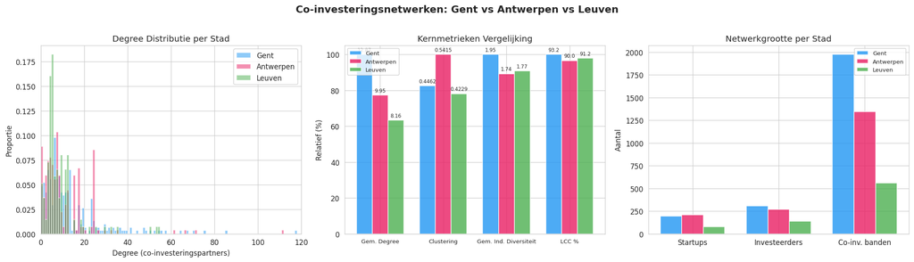

### ⚡ Kernbevinding: Drie Steden, Drie Profielen

| Metriek | Gent | Antwerpen | Leuven |
| --- | --- | --- | --- |
| Investeerders | 307 | 270 | 137 |
| Co-inv. banden | 1.975 | 1.343 | 559 |
| Gem. degree | 12,87 | 9,95 | 8,16 |
| Clustering | 0,45 | **0,54** | 0,42 |
| Densiteit | 0,042 | 0,037 | **0,060** |

**Gent** is de grootste hub (307 investeerders, 1.975 banden) met de hoogste gemiddelde degree (12,87) — het netwerk is breed maar minder hecht. **Antwerpen** springt eruit door de hoogste clustering (0,54): investeerders kennen elkaars partners en investeren in vergelijkbare deals, wat wijst op een meer gesloten, syndicaat-gedreven cultuur. **Leuven** is compact (137 investeerders) maar opvallend dens (0,060) — een klein, hecht netwerk rond deep-tech (imec, KU Leuven).

> **Aandachtspunt**: Antwerpen’s hoge clustering kan een kracht zijn (vertrouwen, due diligence sharing) maar ook een risico (groupthink, beperkte dealflow-vernieuwing). Leuven’s kleine omvang maakt het kwetsbaar bij het vertrek van een enkele hub-investeerder.

```
Totaal unieke investeerders (3 steden): 578
Cross-stad investeerders (actief in 2+ steden): 103
Percentage: 17.8%

=======================Overlap Matrix=======================
                      Gent    Antwerpen     Leuven
           Gent         307          75          52
      Antwerpen          75         270          42
         Leuven          52          42         137


Top 15 Cross-Stad Investeerders:
Investeerder                               Steden Actief in
--------------------------------------------------------------------------------
Angelwise                                    3    Gent, Antwerpen, Leuven
Belfius                                      3    Gent, Antwerpen, Leuven
Capricorn Partners                           3    Gent, Antwerpen, Leuven
EIT Health                                   3    Gent, Antwerpen, Leuven
ESA Space Solutions Belgium                  3    Gent, Antwerpen, Leuven
European Innovation Council                  3    Gent, Antwerpen, Leuven
Flanders Institute for Biotechnology         3    Gent, Antwerpen, Leuven
Fortino Capital Partners                     3    Gent, Antwerpen, Leuven
Gemma Frisius Fund - GFF                     3    Gent, Antwerpen, Leuven
Ghent University                             3    Gent, Antwerpen, Leuven
Gilles Mattelin                              3    Gent, Antwerpen, Leuven
Joris Van Der Gucht                          3    Gent, Antwerpen, Leuven
Jorn Vanysacker                              3    Gent, Antwerpen, Leuven
KBC                                          3    Gent, Antwerpen, Leuven
KU Leuven                                    3    Gent, Antwerpen, Leuven
```

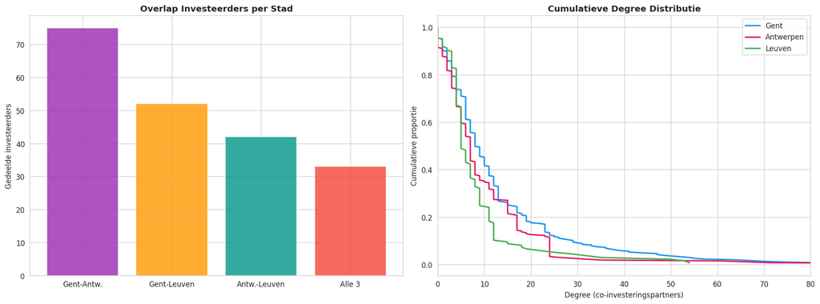

```
===========Samenvatting Cross-Stad Connectiviteit===========
Gent ∩ Antwerpen:  75 investeerders
Gent ∩ Leuven:     52 investeerders
Antwerpen ∩ Leuven: 42 investeerders
Alle 3 steden:      33 investeerders
```

### ⚡ Aandachtspunt: Het “Drie Eilanden”-Probleem

Van de 578 unieke investeerders in de drie steden is slechts **103 (17,8%) actief in twee of meer steden**. Het overgrote deel — 82,2% — investeert exclusief binnen één stad. Nog opvallender: slechts **33 investeerders** zijn als brug actief in alle drie de steden, waarvan het merendeel institutioneel (PMV, Start it @KBC, imec.istart, KU Leuven, …).

De overlap is asymmetrisch:

- **Gent ↔ Antwerpen**: 75 gedeelde investeerders (sterkste corridor)
- **Gent ↔ Leuven**: 52 gedeelde investeerders
- **Antwerpen ↔ Leuven**: 42 gedeelde investeerders (zwakste corridor)

> **Implicatie**: Het Vlaamse co-investeringsnetwerk functioneert grotendeels als **drie gescheiden eilanden**, verbonden door een dunne institutionele brug. Als PMV of Start it @KBC hun strategie wijzigt, verzwakt de enige substantieel cross-regionale verbinding. Dit is een structurele kwetsbaarheid.

```
===========================SECTOR DOMINANTIE PER STAD===========================


Gent (totaal 515 sector-tags):
  health                          112 ( 21.7%) █████████████████████
  enterprise software              89 ( 17.3%) █████████████████
  food                             46 (  8.9%) ████████
  marketing                        39 (  7.6%) ███████
  transportation                   25 (  4.9%) ████
  media                            21 (  4.1%) ████
  security                         19 (  3.7%) ███
  real estate                      16 (  3.1%) ███
  energy                           15 (  2.9%) ██
  fintech                          14 (  2.7%) ██

Antwerpen (totaal 511 sector-tags):
  health                           77 ( 15.1%) ███████████████
  enterprise software              68 ( 13.3%) █████████████
  energy                           40 (  7.8%) ███████
  fintech                          39 (  7.6%) ███████
  marketing                        38 (  7.4%) ███████
  transportation                   36 (  7.0%) ███████
  food                             31 (  6.1%) ██████
  wellness beauty                  22 (  4.3%) ████
  security                         17 (  3.3%) ███
  real estate                      15 (  2.9%) ██

Leuven (totaal 253 sector-tags):
  health                           63 ( 24.9%) ████████████████████████
  enterprise software              26 ( 10.3%) ██████████
  security                         24 (  9.5%) █████████
  fintech                          21 (  8.3%) ████████
  telecom                          16 (  6.3%) ██████
  space                            15 (  5.9%) █████
  energy                           11 (  4.3%) ████
  transportation                   10 (  4.0%) ███
  semiconductors                    9 (  3.6%) ███
  wellness beauty                   8 (  3.2%) ███
```

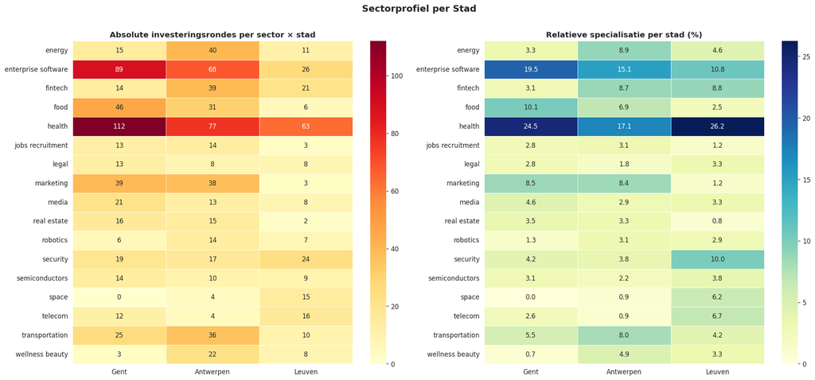

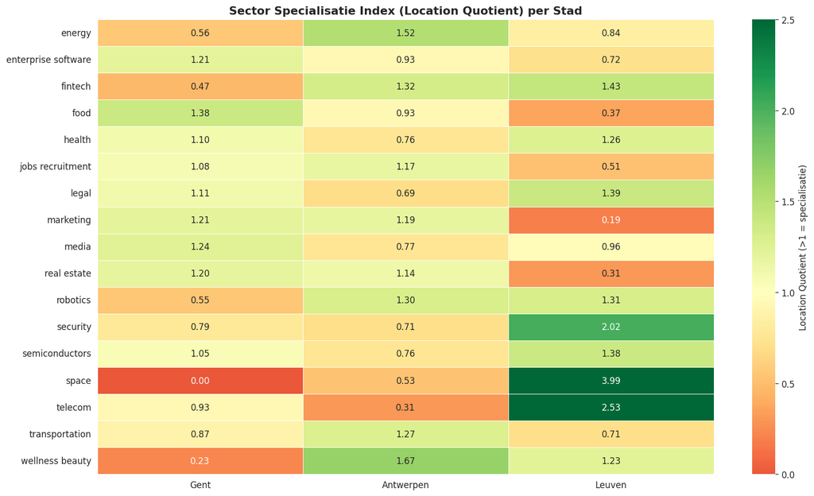

```
======================SPECIALISATIES (LQ > 1.3)=======================

Gent:
  food                           LQ = 1.38

Antwerpen:
  wellness beauty                LQ = 1.67
  energy                         LQ = 1.52
  fintech                        LQ = 1.32

Leuven:
  space                          LQ = 3.99
  telecom                        LQ = 2.53
  security                       LQ = 2.02
  fintech                        LQ = 1.43
  legal                          LQ = 1.39
  semiconductors                 LQ = 1.38
  robotics                       LQ = 1.31
```

```
========================SECTOR OVERLAP ANALYSE========================

Gent: 21 significante sectoren
Antwerpen: 20 significante sectoren
Leuven: 15 significante sectoren

Gedeeld door alle 3 steden (12):
  • education
  • energy
  • enterprise software
  • fintech
  • food
  • health
  • legal
  • media
  • robotics
  • security
  • semiconductors
  • transportation

===========Unieke sectoren per stad (≥5 investeringsrondes)===========

Gent — uniek:
  • chemicals (6 investeringsrondes)
  • sports (10 investeringsrondes)

Antwerpen — uniek:
  • travel (9 investeringsrondes)

Leuven — uniek:
  • space (15 investeringsrondes)
```

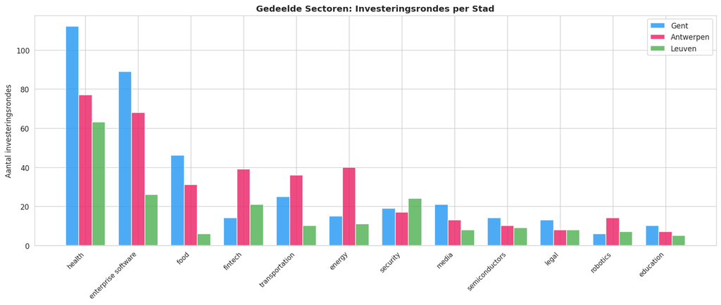

### ⚡ Sectorale Specialisatie: Elke Stad Heeft een DNA

De Location Quotient (LQ) analyse onthult duidelijke specialisatiepatronen:

[output not shown]

De **kern van 12 sectoren** (health, enterprise software, food, transportation, energy, fintech, security, robotics, semiconductors, education, media, legal) is in alle drie steden aanwezig, maar de **periferie verschilt sterk**: Leuven heeft een unieke space-cluster (15 investeringen), Gent heeft sports (10) en chemicals (6), Antwerpen heeft travel (9).

> **Aandachtspunt**: De sectorale complementariteit is een sterk punt — de drie steden concurreren nauwelijks met elkaar. Leuven's extreme specialisatie (space LQ bijna 4×) maakt het wereldwijd relevant in een niche, maar ook kwetsbaar bij sectorale tegenwind. Een gecoördineerd sectorbeleid kan inspelen op deze complementariteit.

## Sector-Shift per Stad (2019–2021 vs 2022–2025)

Welke sectoren groeien en welke nieuwe domeinen ontstaan per stad? Vergelijking van de "vroege" periode (2019–2021) met de "late" periode (2022–2025).

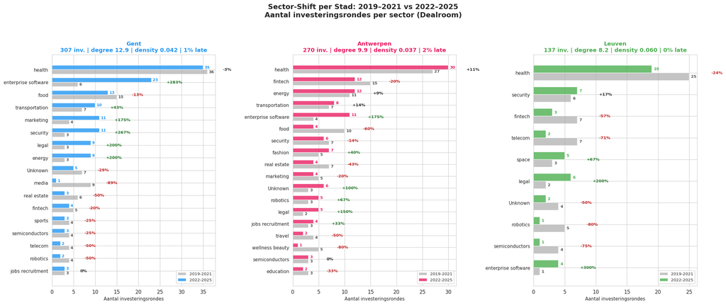

```
  Gent: geen volledig nieuwe sectoren (2+ deals)
  Antwerpen nieuwe sectoren: media (3)
  Leuven nieuwe sectoren: transportation (4), jobs recruitment (3)
```

## Temporele Evolutie per Stad (2019–2025)

Hoe zijn de co-investeringsnetwerken van Gent, Antwerpen en Leuven gegroeid over de jaren?

[output not shown]

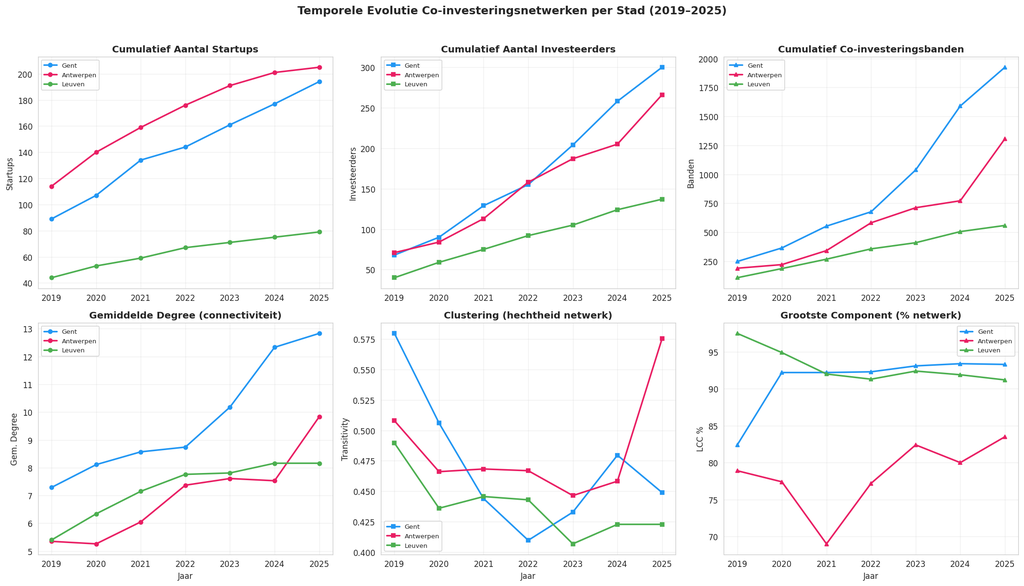

```
=================GROEIANALYSE PER STAD (2019 → 2025)==================


Gent:
  Metriek                       2019     2025    Groei     CAGR
  ---------------------------------------------------------
  Startups                      89.0    194.0     118%   13.9%
  Investeerders                 68.0    300.0     341%   28.1%
  Co-inv. banden               248.0   1924.0     676%   40.7%
  Gem. Degree                    7.3     12.8      76%    9.9%

Antwerpen:
  Metriek                       2019     2025    Groei     CAGR
  ---------------------------------------------------------
  Startups                     114.0    205.0      80%   10.3%
  Investeerders                 71.0    266.0     275%   24.6%
  Co-inv. banden               190.0   1307.0     588%   37.9%
  Gem. Degree                    5.3      9.8      84%   10.7%

Leuven:
  Metriek                       2019     2025    Groei     CAGR
  ---------------------------------------------------------
  Startups                      44.0     79.0      80%   10.2%
  Investeerders                 40.0    137.0     242%   22.8%
  Co-inv. banden               108.0    559.0     418%   31.5%
  Gem. Degree                    5.4      8.2      51%    7.1%


=====================RELATIEVE GROEI (2019 = 100)=====================
```

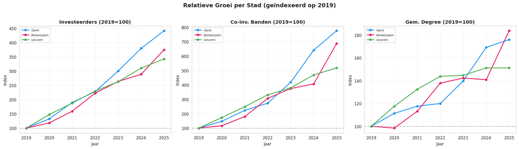

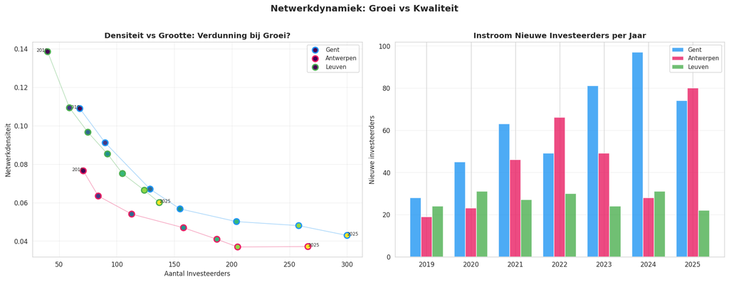

```
===============CONCLUSIE DENSITEIT-VERDUNNING===============
        Gent: densiteit 0.1089 → 0.0429 (-61%)
   Antwerpen: densiteit 0.0765 → 0.0371 (-52%)
      Leuven: densiteit 0.1385 → 0.0600 (-57%)
```

### ⚡ Aandachtspunt: De Groeiparadox — Meer Investeerders, Lossere Netwerken

Alle drie steden tonen **explosieve groei** sinds 2019:

| Stad | Investeerders CAGR | Banden CAGR | Degree groei |
| --- | --- | --- | --- |
| Gent | +28% p.j. | +41% p.j. | +76% totaal |
| Antwerpen | +24,5% p.j. | +37,9% p.j. | +83% totaal |
| Leuven | +22,8% p.j. | +31,5% p.j. | +51% totaal |

Maar de **netwerkdensiteit daalt dramatisch**:

- Gent: 0,109 → 0,043 (**−61%**)
- Antwerpen: 0,077 → 0,037 (**−52%**)
- Leuven: 0,139 → 0,060 (**−57%**)

> **Beleidsimplicatie**: Pure instroom van nieuwe investeerders is onvoldoende — er is actief **netwerk-weefbeleid** nodig (matchmaking-events, co-investmentprogramma’s) om de verdunning tegen te gaan. Antwerpen verliest het minst (-52%), mogelijk door sterkere syndicaat-cultuur.

### ⚡ Synthese: Is Vlaanderen Meer dan de Som der Delen?

Maar het totaalnetwerk scoort **slechter** op:

- **Clustering**: 0,27 vs 0,47 gemiddeld per stad (**−42%**) — de hechtheid verdampt op Vlaams niveau

Het totaalnetwerk scoort **beter** op degree:

- **Degree**: 11,8 vs 10,3 gemiddeld (**+14%**) — investeerders winnen beperkt partners bij via cross-stad syndicaten

De conclusie is genuanceerd: Vlaanderen wint **bereik** (meer banden, hogere degree, meer sectoren) maar verliest **hechtheid** (clustering −42%). De cross-stad banden voegen partners toe maar zijn minder geclusterd — ze verbinden de eilanden zonder de lokale netwerkhechtheid te versterken.

## 📋 Samenvatting & Aandachtspunten voor Beleid

### Beleidsaandachtspunten

[output not shown]

*Dit is NB7, het afsluitende vergelijkingsnotebook. Bouwt voort op NB1 (resilience), NB2 (exits & netwerk), NB3 (recycling) en NB4 (kapitaalreproductie). Zie NB6 (Policy Framework) voor de geïntegreerde beleidsaanbevelingen.*

## Temporele Evolutie per Sector × Stad

Hoe ontwikkelen de co-investeringsnetwerken zich over de tijd voor de **vijf dominante sectoren** (health, enterprise software, food, transportation, energy) in elk van de drie steden?

```
Sector-stad combinaties gebouwd:
  Health: Gent, Antwerpen, Leuven
  Enterprise Software: Gent, Antwerpen, Leuven
  Food: Gent, Antwerpen, Leuven
  Transportation: Gent, Antwerpen, Leuven
  Energy: Gent, Antwerpen, Leuven
```

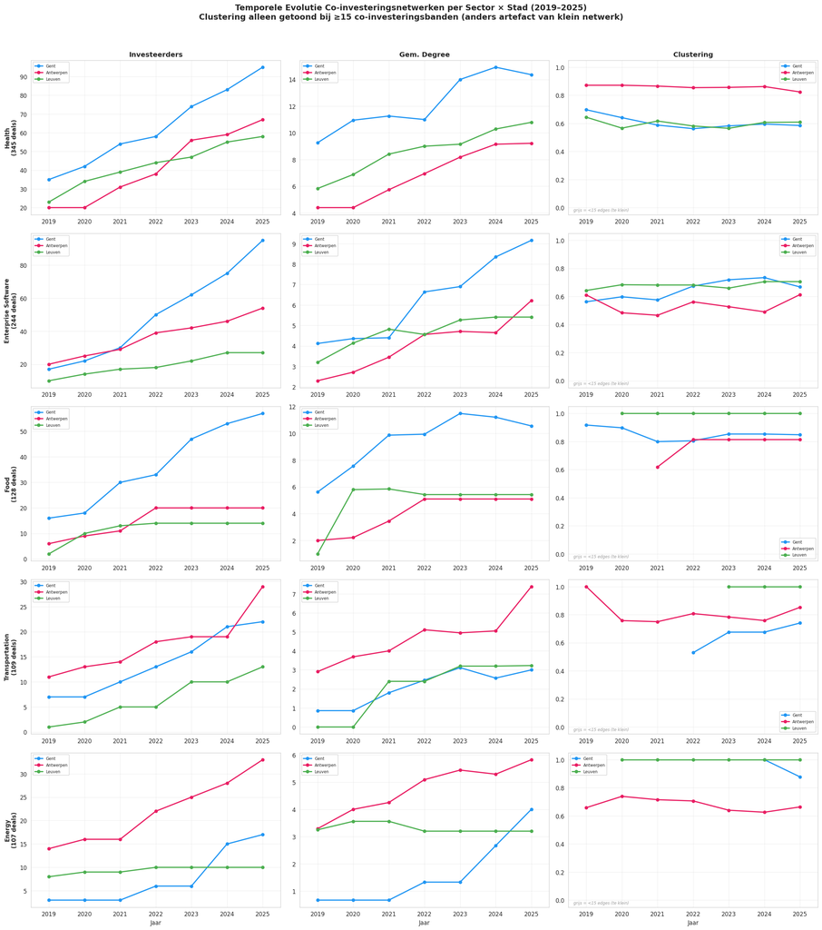

```
=======================SECTOR × STAD SNAPSHOT (2025)=======================
Sector                 Stad           Inv  Edges  Degree  Clust.
--------------------------------------------------------------
Health                 Gent            95    682    14.4   0.585
Health                 Antwerpen       67    309     9.2   0.824
Health                 Leuven          58    313    10.8   0.609
Enterprise Software    Gent            95    435     9.2   0.668
Enterprise Software    Antwerpen       54    168     6.2   0.614
Enterprise Software    Leuven          27     73     5.4   0.706
Food                   Gent            57    301    10.6   0.848
Food                   Antwerpen       20     51     5.1   0.814
Food                   Leuven          14     38     5.4   1.000
Transportation         Gent            22     33     3.0   0.741
Transportation         Antwerpen       29    107     7.4   0.852
Transportation         Leuven          13     21     3.2   1.000
Energy                 Gent            17     34     4.0   0.878
Energy                 Antwerpen       33     96     5.8   0.664
Energy                 Leuven          10     16     3.2   1.000
```

[interactive chart not shown]

```
✅ Geëxporteerd naar: /Volumes/afdeling_vlaio_netwerk_prd/analist/analist/Experiments/SU-SCU/Output/sector_evolutie_per_stad.html
   Bestandsgrootte: 31 KB
   Interactief: hover, zoom, pan, download als PNG
```

## Waarom verschilt de degree tussen sectoren?

### Decompositie: investeerdersaccumulatie × funnel-diepte × hub-concentratie

De gemiddelde degree loopt sterk uiteen per sector (health ~11 vs energy ~5 gemiddeld over 3 steden). Drie mechanismen verklaren het verschil:

1. **Unieke investeerders per startup** — hoeveel co-investeerders accumuleert een startup over alle rondes heen?
2. **Rondes per startup** (funnel-diepte) — meer rondes = meer verschillende investeerder-combinaties
3. **Hub-concentratie** — hoeveel % van startups wordt bereikt door de top-3 investeerders (clique-vorming)?

Belangrijk: de syndicaatsgrootte **per ronde** (~1.8 inv/ronde) verschilt nauwelijks tussen sectoren. Het verschil ontstaat door **accumulatie over meerdere rondes** en **hub-effecten**.

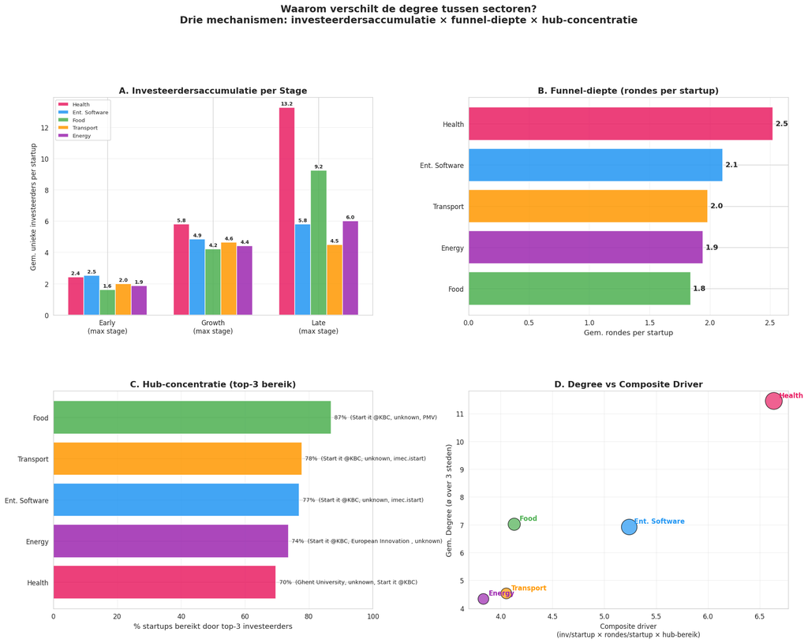

[output not shown]

## Vergelijking: Steden vs Totaal Vlaams Netwerk

Is het totale ecosysteem meer dan de som der delen? Of is het slechts een aggregatie van drie geïsoleerde stadsnetwerken?

```
Vergelijking: Steden vs Totaal Vlaanderen
```

```
===============IS HET TOTAAL MEER DAN DE SOM DER DELEN?===============

  Unieke investeerders           Totaal:      723   Som steden:      714   Ratio: 1.01x (+1%)
  Co-investeringsbanden          Totaal:     4252   Som steden:     3877   Ratio: 1.10x (+10%)
  Gem. co-inv. partners          Totaal:    11.76   Som steden:    10.33   Ratio: 1.14x (+14%)
  Clustering                     Totaal:   0.2735   Som steden:   0.4702   Ratio: 0.58x (-42%)
  Industrie diversiteit          Totaal:     1.94   Som steden:     1.82   Ratio: 1.07x (+7%)

==========================CROSS-STAD BANDEN===========================
  Totaal banden in Vlaanderen:         4252
  Som banden binnen steden:            3674
  Cross-stad banden (meerwaarde):       578  (13.6% van totaal)

  → 578 banden bestaan ALLEEN doordat investeerders
    in startups uit verschillende steden investeren.
```

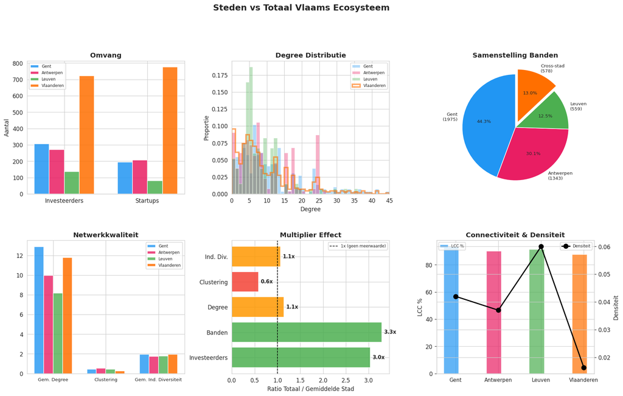

[figure not shown]

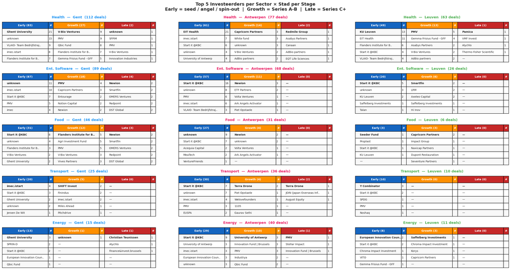

```
===================TOP INVESTEERDER PER SECTOR × STAD × STAGE===================
Sector           Stad         Early                        Growth                       Late
————————————————————————————————————————————————————————————————————————————————————————————————————
Health          Gent        Ghent University (21)          V-Bio Ventures (9)            unknown (1)
Health          Antwerpen   EIT Health (21)                Capricorn Partners (3)        Redmile Group (1)
Health          Leuven      KU Leuven (13)                 PMV (5)                       Pamica (1)
Ent. Software   Gent        unknown (11)                   PMV (4)                       Newion (2)
Ent. Software   Antwerpen   Start it @KBC (16)             Newion (3)                    —
Ent. Software   Leuven      Start it @KBC (5)             Smartfin (2)                  —
Food            Gent        Start it @KBC (8)             Flanders Institute f (5)      Newion (2)
Food            Antwerpen   unknown (9)                   Newion (2)                    —
Food            Leuven      Seeder Fund (1)               Capricorn Partners (2)        —
Transport       Gent        imec.istart (4)               SHIFT Invest (2)              —
Transport       Antwerpen   Start it @KBC (7)             Terra Drone (2)               Terra Drone (1)
Transport       Leuven      Y Combinator (3)              —                           —
Energy          Gent        Ghent University (3)          unknown (1)                   Christian Teunissen (1)
Energy          Antwerpen   Start it @KBC (9)             University of Antwer (3)      PMV (1)
Energy          Leuven      European Innovation  (2)      Saffelberg Investmen (1)      —
```

```
✅ Geëxporteerd naar: /Volumes/afdeling_vlaio_netwerk_prd/analist/analist/Experiments/SU-SCU/Output/top5_investeerders_sector_stad_stage.html
   Bestandsgrootte: 17 KB
   15 kaarten (5 sectoren × 3 steden), interactief CSS grid
```